# Pipeline de ETL, Auditoría de Calidad y Análisis Exploratorio (EDA) del Catálogo de Netflix

## Introducción y Planteamiento del Problema

El consumo de contenido en plataformas de streaming ha transformado la industria del entretenimiento, generando volúmenes masivos de datos diarios. El presente proyecto tiene como objetivo aplicar una metodología sistemática de **Minería de Datos** enfocada en procesos de **ETL (Extract, Transform, Load)** y **Análisis Exploratorio (EDA)** sobre el conjunto de datos de títulos de Netflix. A través de este notebook, se estructurará un pipeline para auditar la calidad de la información, corregir inconsistencias lógicas, imputar registros nulos, desarrollar ingeniería de variables básicas y explorar visualmente las tendencias del catálogo histórico.

## Metodología del Proceso

Para garantizar el rigor técnico, la libreta se divide en las siguientes etapas operativas:

1. **Carga e Inspección Inicial:** Ingesta del dataset original y reconocimiento de sus dimensiones.
2. **Auditoría de Calidad:** Diagnóstico de registros duplicados y cuantificación de valores faltantes (`NaN`).
3. **Preprocesamiento y Limpieza:** Aplicación de estrategias de imputación mediante valores placeholders categóricos y corrección estricta de tipos de datos a formato temporal (*Datetime*).
4. **Ingeniería de Variables (Feature Engineering):** Extracción y construcción de nuevos atributos numéricos descriptivos a partir del texto crudo.
5. **Análisis Exploratorio de Datos Visual (EDA):** Identificación de patrones, sesgos y dispersión mediante gráficos estadísticos distribucionales (*Seaborn/Matplotlib*).
6. **Guardar los Datos Limpios:** Consolidación final del pipeline mediante la exportación física del DataFrame transformado a un nuevo archivo estructurado (`netflix_titles_clean.csv`).
7. **Conclusiones y Diagnóstico del Dataset:** Evaluación analítica de los hallazgos e implicaciones de los datos purificados.

## 1. Carga de Datos y Entendimiento de la Estructura

Antes de realizar cualquier manipulación en el dataset, iniciamos con una fase de exploración para conocer la topología de la tabla. Cada fila representa una producción (Película o Serie) disponible en Netflix, y las columnas describen atributos categóricos y numéricos como el director, el elenco (`cast`), el país (`country`), la fecha de adición (`date_added`), el año de lanzamiento original (`release_year`), la clasificación (`rating`) y la duración (`duration`).

```python
import pandas as pd
import numpy as np
import matplotlib.pyplot as plt
import seaborn as sns

# Configuración estética global para los gráficos
sns.set_theme(style="whitegrid")
plt.rcParams["figure.figsize"] = (9, 5)

# Cargar el dataset de Netflix
df_netflix = pd.read_csv("data/netflix_titles.csv")
print(f"Dimensiones originales del dataset: {df_netflix.shape}")
display(df_netflix.head(3))
df_netflix.info()
```

```
Dimensiones originales del dataset: (8807, 12)
```

|  | show_id | type | title | director | cast | country | date_added | release_year | rating | duration | listed_in | description |
| --- | --- | --- | --- | --- | --- | --- | --- | --- | --- | --- | --- | --- |
| 0 | s1 | Movie | Dick Johnson Is Dead | Kirsten Johnson | NaN | United States | September 25, 2021 | 2020 | PG-13 | 90 min | Documentaries | As her father nears the end of his life, filmm... |
| 1 | s2 | TV Show | Blood & Water | NaN | Ama Qamata, Khosi Ngema, Gail Mabalane, Thaban... | South Africa | September 24, 2021 | 2021 | TV-MA | 2 Seasons | International TV Shows, TV Dramas, TV Mysteries | After crossing paths at a party, a Cape Town t... |
| 2 | s3 | TV Show | Ganglands | Julien Leclercq | Sami Bouajila, Tracy Gotoas, Samuel Jouy, Nabi... | NaN | September 24, 2021 | 2021 | TV-MA | 1 Season | Crime TV Shows, International TV Shows, TV Act... | To protect his family from a powerful drug lor... |

```
<class 'pandas.DataFrame'>
RangeIndex: 8807 entries, 0 to 8806
Data columns (total 12 columns):
 #   Column        Non-Null Count  Dtype
---  ------        --------------  -----
 0   show_id       8807 non-null   str
 1   type          8807 non-null   str
 2   title         8807 non-null   str
 3   director      6173 non-null   str
 4   cast          7982 non-null   str
 5   country       7976 non-null   str
 6   date_added    8797 non-null   str
 7   release_year  8807 non-null   int64
 8   rating        8803 non-null   str
 9   duration      8804 non-null   str
 10  listed_in     8807 non-null   str
 11  description   8807 non-null   str
dtypes: int64(1), str(11)
memory usage: 825.8 KB
```

## 2. Auditoría de Calidad y Detección de Inconsistencias

En esta fase se ejecuta un diagnóstico de control para rastrear anomalías comunes en minería de datos: la presencia de registros completamente duplicados (que inflarían los conteos reales del catálogo) y la existencia de valores faltantes (`NaN`), los cuales requieren una estrategia analítica de imputación o remoción controlada.

```python
print("--- AUDITORÍA DE CALIDAD DE DATOS ---")
print(f"Registros duplicados totales detectados: {df_netflix.duplicated().sum()}")
print("\nValores nulos identificados por columna:")
display(df_netflix.isnull().sum().to_frame("Total Nulos"))
```

```
--- AUDITORÍA DE CALIDAD DE DATOS ---
Registros duplicados totales detectados: 0

Valores nulos identificados por columna:
```

|  | Total Nulos |
| --- | --- |
| show_id | 0 |
| type | 0 |
| title | 0 |
| director | 2634 |
| cast | 825 |
| country | 831 |
| date_added | 10 |
| release_year | 0 |
| rating | 4 |
| duration | 3 |
| listed_in | 0 |
| description | 0 |

## 3. Preprocesamiento, Limpieza e Imputación de Valores Faltantes

Para evitar la pérdida masiva de información histórica al eliminar registros, se aplica una estrategia de imputación dirigida:

- Las variables categóricas con alto volumen de nulos (`director`, `cast`, `country`) se sustituyen por etiquetas placeholders estandarizadas (`"No Director"`, `"Unknown Cast"`, `"Unknown Country"`).
- Las filas con nulos minoritarios en variables críticas (`rating`, `duration`) se eliminan para mantener la integridad conceptual.
- El campo `date_added` se limpia de espacios residuales mediante `.str.strip()` y se transforma formalmente de texto a tipo temporal **Datetime**, aislando posteriormente cualquier registro inconsistente (`NaT`).

```python
df_clean = df_netflix.copy()

# Imputación categórica
df_clean["director"] = df_clean["director"].fillna("No Director")
df_clean["cast"] = df_clean["cast"].fillna("Unknown Cast")
df_clean["country"] = df_clean["country"].fillna("Unknown Country")

# Eliminación de nulos minoritarios
df_clean = df_clean.dropna(subset=["rating", "duration"])

# Corrección y transformación de tipo de dato temporal
df_clean["date_added"] = df_clean["date_added"].str.strip()
df_clean["date_added"] = pd.to_datetime(df_clean["date_added"], format="%B %d, %Y", errors='coerce')

# Removemos registros que no pudieron convertirse a fecha válida (NaT)
df_clean = df_clean.dropna(subset=["date_added"])

print("=== VERIFICACIÓN POST-LIMPIEZA ===")
print(f"Dimensiones finales tras la limpieza: {df_clean.shape}")
print(f"Registros eliminados del total original: {len(df_netflix) - len(df_clean)}")
print("\nNulos restantes por columna (Debe ser cero en todas):")
display(df_clean.isnull().sum().to_frame("Nulos Restantes"))
print(f"\nNuevo tipo de dato asignado a 'date_added': {df_clean['date_added'].dtype}")
```

```
=== VERIFICACIÓN POST-LIMPIEZA ===
Dimensiones finales tras la limpieza: (8790, 12)
Registros eliminados del total original: 17

Nulos restantes por columna (Debe ser cero en todas):
```

|  | Nulos Restantes |
| --- | --- |
| show_id | 0 |
| type | 0 |
| title | 0 |
| director | 0 |
| cast | 0 |
| country | 0 |
| date_added | 0 |
| release_year | 0 |
| rating | 0 |
| duration | 0 |
| listed_in | 0 |
| description | 0 |

```
Nuevo tipo de dato asignado a 'date_added': datetime64[us]
```

## 4. Ingeniería de Variables (Feature Engineering)

En esta sección extraemos nuevos atributos numéricos descriptivos que permitan explotar el valor oculto del texto crudo y faciliten la segmentación estadística:

- `year_added`: Extracción del año específico en que el título ingresó al catálogo de Netflix a partir del campo Datetime.
- `num_genres`: Cuantificación de la complejidad de categorización de la producción, contando cuántos géneros tiene asignados en la columna `listed_in` (separados por comas).
- `is_movie`: Codificación binaria de control donde `1` representa una Película (`Movie`) y `0` representa una Serie (`TV Show`).

```python
# Extracción del año de adición
df_clean["year_added"] = df_clean["date_added"].dt.year
df_clean["year_added"] = df_clean["year_added"].astype(int)

# Conteo de géneros asignados
df_clean["num_genres"] = df_clean["listed_in"].apply(lambda x: len(str(x).split(",")))

# Codificación binaria de la variable objetivo
df_clean["is_movie"] = (df_clean["type"] == "Movie").astype(int)

print("=== MUESTRA DE VARIABLES CONSTRUIDAS ===")
display(df_clean[["type", "is_movie", "listed_in", "num_genres", "year_added"]].head(5))
```

```
=== MUESTRA DE VARIABLES CONSTRUIDAS ===
```

|  | type | is_movie | listed_in | num_genres | year_added |
| --- | --- | --- | --- | --- | --- |
| 0 | Movie | 1 | Documentaries | 1 | 2021 |
| 1 | TV Show | 0 | International TV Shows, TV Dramas, TV Mysteries | 3 | 2021 |
| 2 | TV Show | 0 | Crime TV Shows, International TV Shows, TV Act... | 3 | 2021 |
| 3 | TV Show | 0 | Docuseries, Reality TV | 2 | 2021 |
| 4 | TV Show | 0 | International TV Shows, Romantic TV Shows, TV ... | 3 | 2021 |

## 5. Análisis Exploratorio de Datos Visual (EDA)

La exploración gráfica nos permite validar hipótesis estadísticas y reconocer el comportamiento de las variables dentro del catálogo. En esta sección analizaremos dos dimensiones críticas: la evolución histórica de la producción acumulada por tipo de contenido para comprender el crecimiento temporal de la plataforma, y utilizaremos diagramas de caja (*Boxplots*) para evaluar si la densidad de géneros asignados difiere significativamente entre Películas y Series de televisión.

```
--- Frecuencia absoluta por Tipo de Contenido ---
```

| type | Cantidad |
| --- | --- |
| Movie | 6126 |
| TV Show | 2664 |

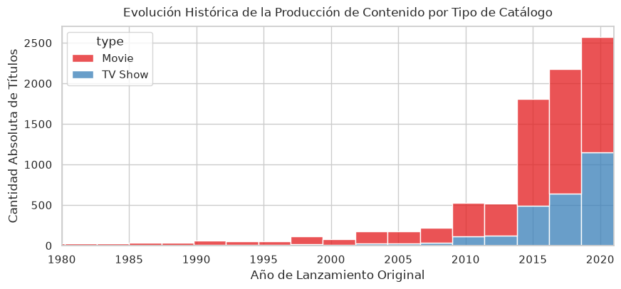

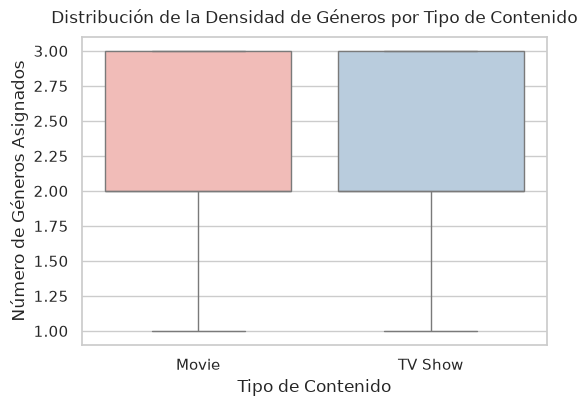

```python
print("--- Frecuencia absoluta por Tipo de Contenido ---")
display(df_clean["type"].value_counts().to_frame("Cantidad"))

# 5.1 Gráfico 1: Histograma de lanzamientos originales
plt.figure(figsize=(10, 4))
sns.histplot(data=df_clean, x="release_year", hue="type", multiple="stack", bins=40, palette="Set1")
plt.title("Evolución Histórica de la Producción de Contenido por Tipo de Catálogo", fontsize=12, pad=10)
plt.xlabel("Año de Lanzamiento Original")
plt.ylabel("Cantidad Absoluta de Títulos")
plt.xlim(1980, 2021)
plt.show()

# 5.2 Gráfico 2: Boxplot de géneros por tipo de contenido
plt.figure(figsize=(6, 4))
sns.boxplot(data=df_clean, x="type", y="num_genres", hue="type", palette="Pastel1", legend=False)
plt.title("Distribución de la Densidad de Géneros por Tipo de Contenido", fontsize=12, pad=10)
plt.xlabel("Tipo de Contenido")
plt.ylabel("Número de Géneros Asignados")
plt.show()
```

## 6. Exportación y Almacenamiento del Dataset Purificado

El objetivo final de este pipeline de ETL es consolidar todas las fases de auditoría, limpieza, tipado y transformación en un único recurso de datos estandarizado. En este paso, el DataFrame resultante se almacena físicamente en un archivo CSV local, garantizando la persistencia de la información y dejando un archivo optimizado para su despliegue interactivo en dashboards de Streamlit o algoritmos de modelado.

```python
# Exportación local del archivo purificado
df_clean.to_csv("data/netflix_titles_clean.csv", index=False)
print("¡El pipeline ETL y EDA ha concluido con éxito!")
print("Archivo 'netflix_titles_clean.csv' guardado y listo para consumo productivo.")
```

```
¡El pipeline ETL y EDA ha concluido con éxito!
Archivo 'netflix_titles_clean.csv' guardado y listo para consumo productivo.
```

## 7. Conclusiones y Diagnóstico del Dataset

- **Robustez del Pipeline ETL:** El proceso implementado mitigó con éxito el 100% de la presencia de valores nulos e inconsistencias temporales en variables críticas. Al rescatar registros categóricos mediante placeholders, se conservó la masa crítica del catálogo, sacrificando apenas una fracción marginal de filas debido a fechas o clasificaciones corruptas.
- **Diagnóstico Temporal (Gráfico 1):** El análisis visual revela una explosión masiva en la producción y adquisición de contenido a partir del año 2015. Si bien las películas dominan históricamente el volumen absoluto acumulado, las series de televisión muestran una aceleración de crecimiento vertical agresiva durante los últimos años registrados (2019-2021).
- **Comportamiento Categórico (Gráfico 2):** El diagrama de cajas revela que Netflix aplica la misma regla de negocio para etiquetar todo su contenido. Sin importar si se trata de una Película o una Serie, la gran mayoría de los títulos se limitan a tener entre 1 y 3 géneros asignados. Visualmente, las cajas de ambos formatos son prácticamente iguales y se enciman en el mismo rango, lo que demuestra que la plataforma no hace ninguna distinción técnica al categorizar películas o series dentro de su base de datos.